# Useful R code — `RMarkdown`

Matthew Malishev @darwinanddavis

Date: 2022-03-13  
`R` version: 3.5.0  
*Corresponding author: matthew.malishev [at] gmail.com  
This document can be found at https://github.com/darwinanddavis/UsefulCode

## Overview

Useful functions and code snippets for building `RMarkdown` docs. *All `R` code is in Rmd file.*

### Split page into three columns (displays best in browser).

*`R` code is in Rmd file.*  
*Check [Tokyo 2020 Olympics medal analysis](https://darwinanddavis.github.io/misc/olympics/olympics.html) for live example*

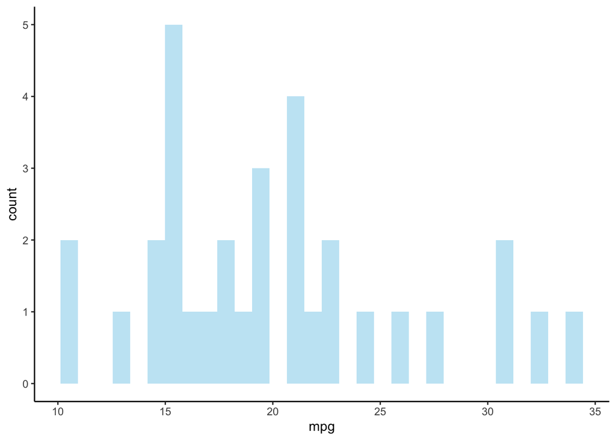

```r
# r plot code
require(ggplot2)
ggplot(mtcars, aes(x = mpg)) + geom_histogram(fill = "skyblue", alpha = 0.5) + theme_classic()
```

> Praise the lord, I was born to travel  
> Feeling like Slash in front of the chapel  
> I'm leaned back with the Les Paul  
> Shit I smoke is like cholesterol  
> Spilled dressin' on the vest at the festival  
> The best of all, had a midget Puerto Rican at my beckon call

Pump the bass in the trunk  
It rattled like a baby hand  
Except this toy cost 80 grand  
And I'm crazy tan, from all the places that I've been  
Just from writing words with a pen

### Inserting text within indented equations

$$p(x) = \theta^{x} (1 - \theta)^{1-x} ~~\mbox{ for }~~x = 0,1$$

### Remove white space around imgs using `fig.asp`

`{r,fig.asp=0.50}`

### Read external Rmd chunks

**Option 1**  
Add this to code chunk: `{r, code = readLines("file.R")}`

**Option 2**

```r
# load r datasets and code chunks
require(dplyr)
paste0(params$here) %>% list.files("r", full.names = T) %>% sapply(knitr::read_chunk)

# or
knitr::read_chunk("external.R")
```

Then in 'external.R' file, add the following header line:  
`# @knitr external`  
Then add this line to the code chunk in the main Rmd file:  
`<<external>>`

### Execute R code in yaml

```yaml
params:
  date: !r Sys.Date()
  email: Your email here
  version: !r getRversion()
```

### Execute `R` code using yaml parameteres

Execute R code from yaml within HTML body

```yaml
params:
  imgdir: "data/plots"
```

```html
# add to rmd
<img src=`r sample(list.files(params$imgdir, full.names = T),1)`>
```

### Change colour of tabs (pills)

```html
<!-- css for tabs -->
<style type="text/css">

.nav>li>a{
    position: relative;
    display: block;
    padding: 10px 15px;
}

.nav-pills>li>a:hover{
  background: `r params$primary`;
  color: `r params$secondary`;
  opacity:0.7;
}

.nav-pills>li>a:focus, .nav-pills>li.active>a, .nav-pills>li.active>a:hover, .nav-pills>li.active>a:focus {
  background: `r params$primary`;
  background-color: `r params$primary`;
}

</style>
```

```markdown
# add to rmd
# Your title {.tabset .tabset-fade .tabset-pills}
```

## Icons

### Feather icons

Add feather icons to Rmd

```html
<!-- for external html e.g. 'footer.html' -->
<!-- feather icons -->
<script src="https://unpkg.com/feather-icons"></script>

<!-- plot icon -->
<p style="text-align: center;">
        <i data-feather="github"></i>
  </p>

<!-- append to end of html file  -->
<!-- feather icons -->
<script>
feather.replace()
</script>
```

```html
<!-- add to rmd -->
<center><i data-feather="chevron-down" class="arrow"></i></center>
```

## Pimping

### Add star ratings to HTML

```r
# install.packages("fivestars", repos = "https://tanho63.r-universe.dev")
library(fivestars)
# set css params
use_fivestars(
  star_size = "15px", # default is "larger"
  star_color = "#001785", # default
  star_background = "#999" # default
)

# example 1
fivestars(rating = 3.5)
```

## Linking external files/code

Insert external HTML file within body

```r
htmltools::includeHTML("index_external.html")
```

Insert external HTML file in header, before body, and footer

```yaml
output:
  html_document:
    includes:
      in_header: header.html
      before_body: before.html
      after_body: after.html
```

## CSS and custom styling

- Put in either 'styles.css' or in .Rmd file body

Change colour/style of crosstalk slider (`crosstalk::filter_slider()`)

```css
/* crosstalk style ---------------- */
.crosstalk-input-slider, .irs-grid-text .irs-text{
  color: #5B3794;
  font-family: Avernir;
}
.js-irs-0 .irs-single, .js-irs-0 .irs-bar-edge, .js-irs-0 .irs-bar {
  color: #5B3794;
  background: #5B3794;
  border-top: 1px solid #5B3794;
  border-bottom: 1px solid #5B3794;
  background-color: #5B3794;
}
```